# E1: Provisional Exploratory Analysis

Alex Kale

2021-02-23

## Exploratory Analysis

Load data.

```r
df <- read_csv("e1-anonymous.csv")
head(df)
```

```
## # A tibble: 6 x 34
##   workerId batch bonus condition duration n_data_conds n_trials gender age
##   <chr>    <dbl> <dbl> <chr>        <dbl>        <dbl>    <dbl> <chr>  <chr>
## 1 6157b65e     4  0.25 filtbars      580.           16       18 woman  45-54
## 2 6157b65e     4  0.25 filtbars      580.           16       18 woman  45-54
## 3 6157b65e     4  0.25 filtbars      580.           16       18 woman  45-54
## 4 6157b65e     4  0.25 filtbars      580.           16       18 woman  45-54
## 5 6157b65e     4  0.25 filtbars      580.           16       18 woman  45-54
## 6 6157b65e     4  0.25 filtbars      580.           16       18 woman  45-54
## # … with 25 more variables: education <chr>, chart_use <chr>, problems <chr>,
## #   abs_err <dbl>, causal_support <dbl>, count_GT <dbl>, count_GnT <dbl>,
## #   count_nGT <dbl>, count_nGnT <dbl>, ground_truth <dbl>, interactions <chr>,
## #   n <dbl>, p_treat <dbl>, payoff <dbl>, q_idx <dbl>, response_A <dbl>,
## #   response_B <dbl>, total_GT <dbl>, total_GnT <dbl>, total_nGT <dbl>,
## #   total_nGnT <dbl>, trial <chr>, trial_dur <dbl>, trial_idx <dbl>,
## #   userInput <chr>
```

Drop practice trial.

```r
df = df %>% filter(trial != "practice")
```

### Exclusions

Let’s exclude workers who miss either the trial where causal support is the largest or the trial where causal support is smallest. We define miss as absolute error greater than 50%.

```r
exclude_df <- df %>%
  group_by(workerId) %>%
  summarise(
    max_trial_idx = which(trial_idx == -1)[1],
    max_trial_gt = ground_truth[[max_trial_idx]],
    max_trial_err = abs_err[[max_trial_idx]],
    min_trial_idx = which(trial_idx == -2)[1],
    min_trial_gt = ground_truth[[min_trial_idx]],
    min_trial_err = abs_err[[min_trial_idx]],
    max_exclude = max_trial_err > 0.5,
    min_exclude = min_trial_err > 0.5,
    exclude = max_trial_err > 0.5 | min_trial_err > 0.5,
  )
head(exclude_df)
```

```
## # A tibble: 6 x 10
##   workerId max_trial_idx max_trial_gt max_trial_err min_trial_idx min_trial_gt
##   <chr>            <int>        <dbl>         <dbl>         <int>        <dbl>
## 1 082f019a             7            1          0.03            13      0.00150
## 2 1046c583            13            1          0.25             7      0.00150
## 3 137a0bcd             7            1          0.25            13      0.00150
## 4 182a0803             7            1          0.34            13      0.00150
## 5 1951b9a0             7            1          0.3             13      0.00150
## 6 1a02cbfe             7            1          0.2             13      0.00150
## # … with 4 more variables: min_trial_err <dbl>, max_exclude <lgl>,
## #   min_exclude <lgl>, exclude <lgl>
```

What proportion of workers are missing each attention check? How many workers are we leaving out with our exclusion criteria?

```r
sum(exclude_df$max_exclude) / length(exclude_df$exclude)
```

```
## [1] 0.2148148
```

```r
sum(exclude_df$min_exclude) / length(exclude_df$exclude)
```

```
## [1] 0.362963
```

```r
sum(exclude_df$exclude) / length(exclude_df$exclude)
```

```
## [1] 0.4740741
```

We’ll proceed without apply our exclusion criteria for now.

### Performance

Let’s start by looking at the over pattern of absolute error. Then we’ll look at the pattern of responses vs ground truth.

#### Absolute error

Here’s the absolute error per trial, separated by sample size and visualization condition.

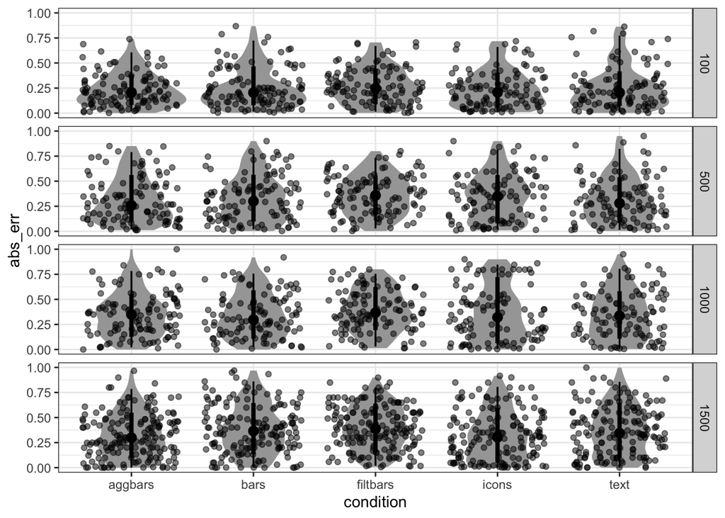

```r
df %>%
  ggplot(aes(x = condition, y = abs_err)) +
    stat_eye() +
    geom_point(position = position_jitter(), alpha = 0.5) +
    theme_bw() +
    facet_grid(n ~ .)
```

Let’s also look at the average absolute error per worker and level of sample size, separated by visualization condition.

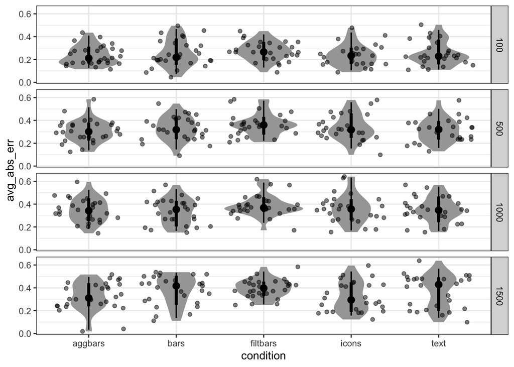

```r
df %>%
  group_by(workerId, condition, n) %>%
  summarise(
    avg_abs_err = mean(abs_err)
  ) %>%
  ungroup() %>%
  ggplot(aes(x = condition, y = avg_abs_err)) +
    stat_eye() +
    geom_point(position = position_jitter(), alpha = 0.5) +
    theme_bw() +
    facet_grid(n ~ .)
```

Absolute error seems to get higher as sample size increases consistent with our pilot. Absolute error seems highest with filtbars and test, unsurprisingly. It looks like aggbars and icons may be especially helpful at high sample size.

Perhaps more striking, absolute error is very high.

#### Responses vs ground truth

Let’s see if we can make better sense of the results by looking at raw responses vs the ground truth. The red line represents perfect performance.

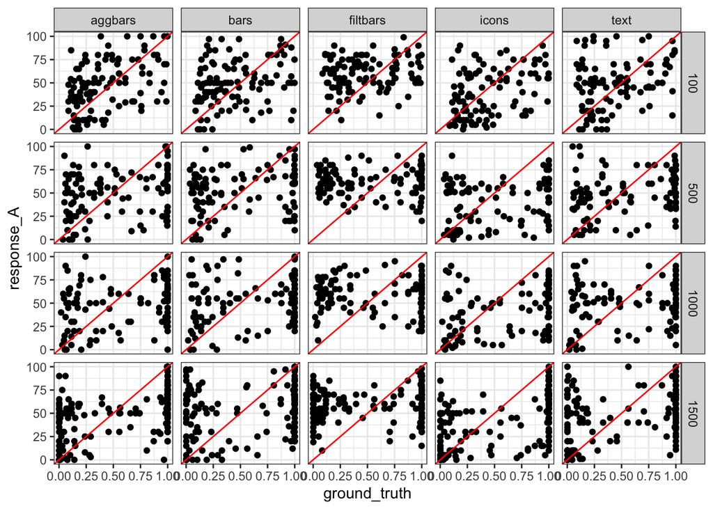

```r
df %>%
  ggplot(aes(x = ground_truth, y = response_A)) +
    geom_point() +
    geom_abline(slope = 100, intercept = 0, color = "red") +
    theme_bw() +
    facet_grid(n ~ condition)
```

We expect to see an inverse S-shaped pattern here (i.e., a linear in log odds pattern with a slope less than one, at least above `ground_truth = 0.5`). To some extent, this is what we see here, but the responses are very noisy.

We expect a linear model to fit these data well in log odds units, so lets sanity check this intuition by looking at causal support (i.e., `logit(ground_truth))` vs the log ratio of responses.

```r
df = df %>%
  mutate(
    # adjust response units
    response_A = if_else(
      response_A > 99.5, 99.5,
      if_else(
        response_A < 0.5, 0.5,
        as.numeric(response_A))),
    response_B = if_else(
      response_B > 99.5, 99.5,
      if_else(
        response_B < 0.5, 0.5,
        as.numeric(response_B))),
    # calculate log response ratio
    lrr = log(response_A / 100) - log(response_B / 100)
  )
```

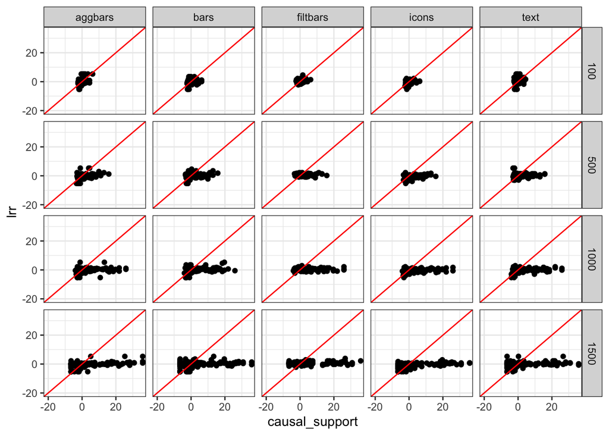

```r
df %>%
  ggplot(aes(x = causal_support, y = lrr)) +
    geom_point() +
    geom_abline(slope = 1, intercept = 0, color = "red") +
    coord_cartesian(
      xlim = c(-20, 35),
      ylim = c(-20, 35)
    ) +
    theme_bw() +
    facet_grid(n ~ condition)
```

This doesn’t look as informative as I’d like because the sampling of the ground truth is so heavily influenced by sample size. Let’s look at each level of sample size on it’s own axis scale.

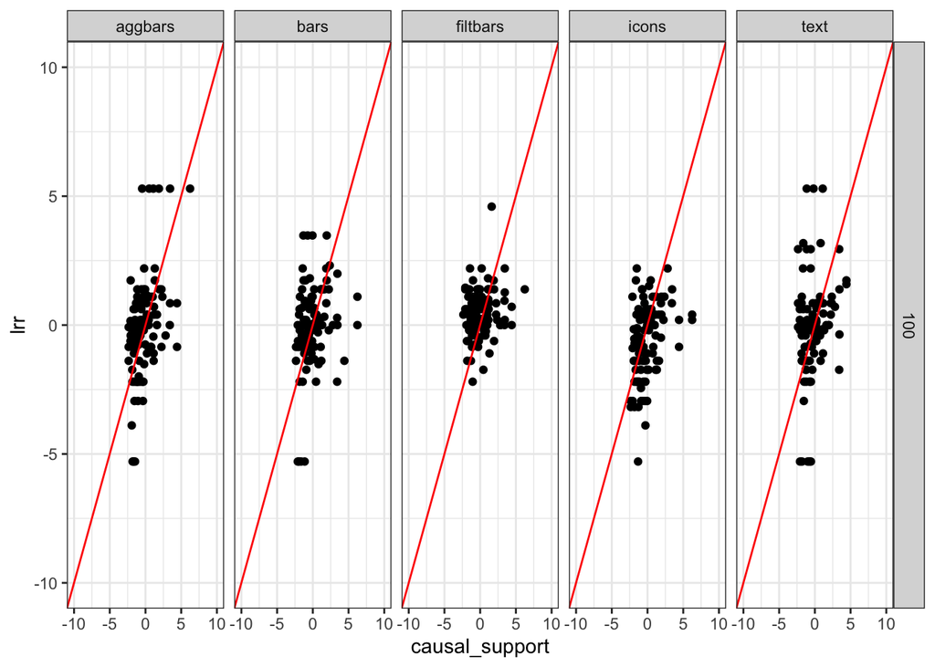

```r
df %>%
  filter(n == 100) %>%
  ggplot(aes(x = causal_support, y = lrr)) +
    geom_point() +
    geom_abline(slope = 1, intercept = 0, color = "red") +
    coord_cartesian(
      xlim = c(-10, 10),
      ylim = c(-10, 10)
    ) +
    theme_bw() +
    facet_grid(n ~ condition)
```

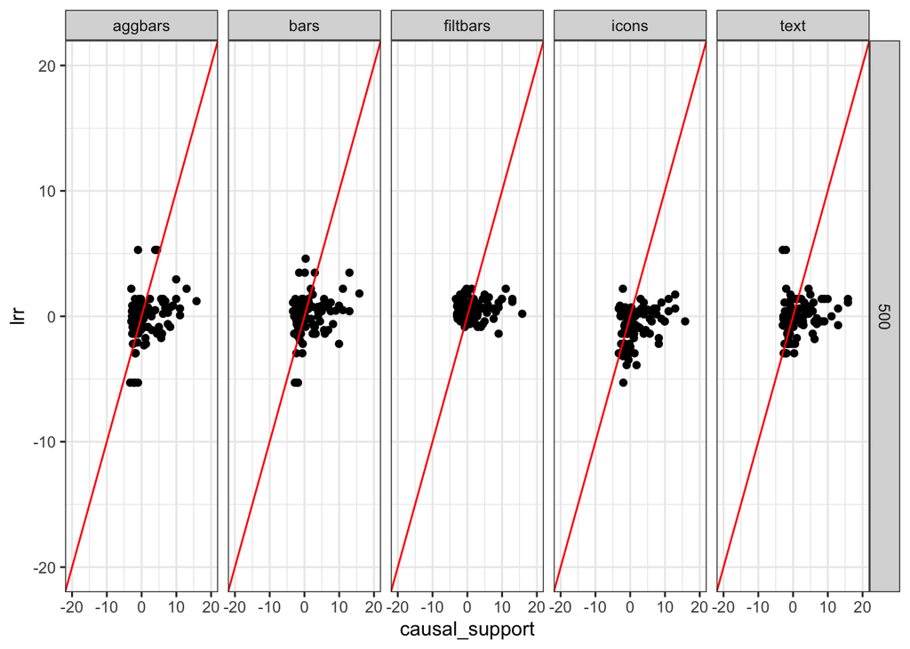

```r
df %>%
  filter(n == 500) %>%
  ggplot(aes(x = causal_support, y = lrr)) +
    geom_point() +
    geom_abline(slope = 1, intercept = 0, color = "red") +
    coord_cartesian(
      xlim = c(-20, 20),
      ylim = c(-20, 20)
    ) +
    theme_bw() +
    facet_grid(n ~ condition)
```

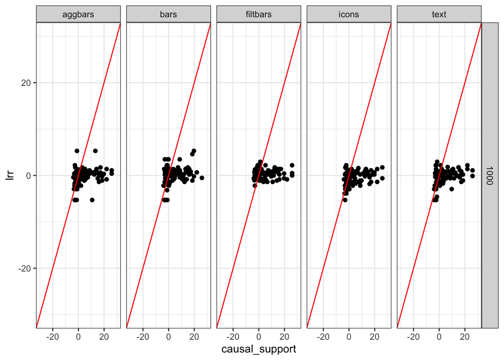

```r
df %>%
  filter(n == 1000) %>%
  ggplot(aes(x = causal_support, y = lrr)) +
    geom_point() +
    geom_abline(slope = 1, intercept = 0, color = "red") +
    coord_cartesian(
      xlim = c(-30, 30),
      ylim = c(-30, 30)
    ) +
    theme_bw() +
    facet_grid(n ~ condition)
```

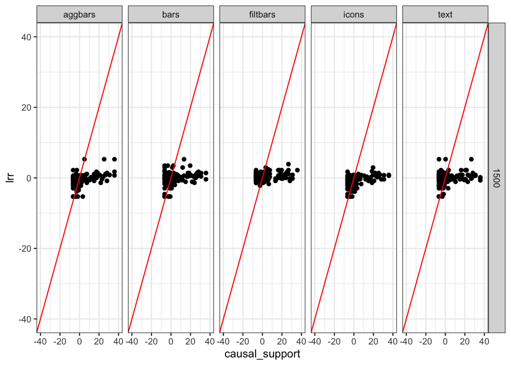

```r
df %>%
  filter(n == 1500) %>%
  ggplot(aes(x = causal_support, y = lrr)) +
    geom_point() +
    geom_abline(slope = 1, intercept = 0, color = "red") +
    coord_cartesian(
      xlim = c(-40, 40),
      ylim = c(-40, 40)
    ) +
    theme_bw() +
    facet_grid(n ~ condition)
```

It seems clear that slopes will be less than 1 in logit-logit coordinate space, at least for all but the smallest sample size, and that slopes are different on either side of `causal_support = 0`. We’ll want to make sure our model can account for this pattern.

One thing that stands out on these charts is that **the ability to discriminate signal decreases at higher sample size**. Although we expect to see people underestimate sample size, the logit-logit slope flattening out as the weight of evidence increases is an interesting pattern.

The level of response noise is concerning to me, but it does seem better than in the pilot. For example, relatively few log response ratios on the wrong side of 0 (i.e., responses on the wrong side of 50%). This means that much of the time people are correctly judging the direction of effect

### Response times

Let’s see a histogram of response times per trial. These are measured in seconds.

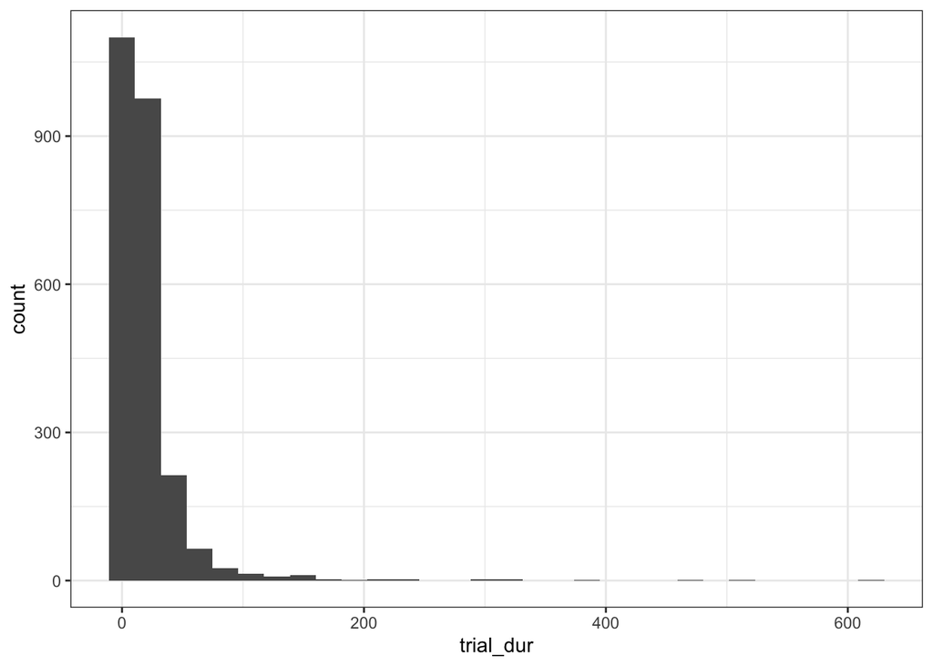

```r
df %>%
  filter(trial_dur >= 0) %>%
  ggplot(aes(x = trial_dur)) +
   geom_histogram() +
    theme_bw()
```

As expected, this looks like a power law distribution.

Let’s separate this by condition to see if icons or text is taking systematically longer.

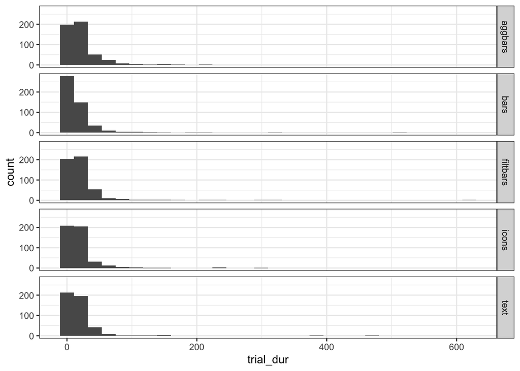

```r
df %>%
  filter(trial_dur >= 0) %>%
  ggplot(aes(x = trial_dur)) +
    geom_histogram() +
    theme_bw() +
    facet_grid(condition ~ .)
```

These distributions look similar. Maybe bars take slightly less time than other conditions.

What about the duration of the experiment per participant?

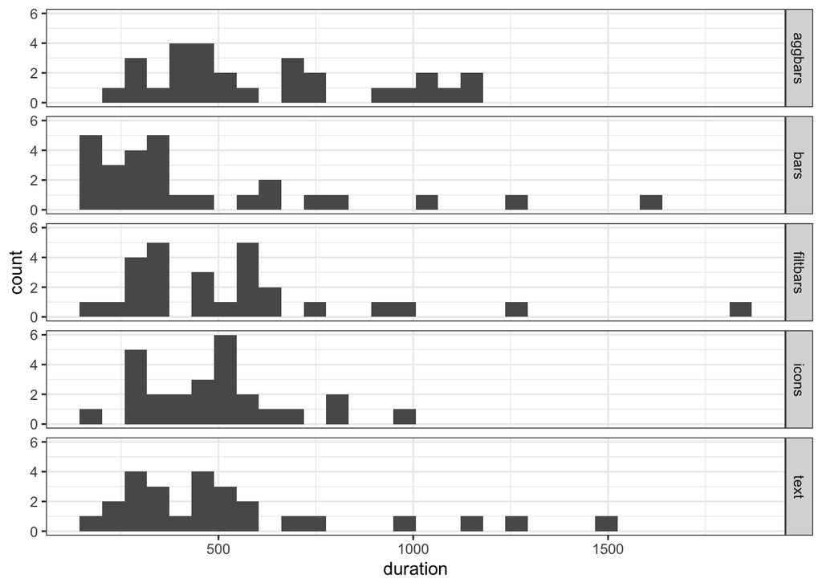

```r
df %>%
  filter(duration >= 0) %>%
  filter(trial == 1) %>%
  ggplot(aes(x = duration)) +
    geom_histogram() +
    theme_bw() +
    facet_grid(condition ~ .)
```

Again these, look pretty similar. There’s a subgroup of people who seem to take longer with aggbars. Honestly the response time data is not too interesting, but it’s worth checking.

### Demographics

Let’s check out out demographic variables in aggregate just to get a sense of our sample composition.

We did a free response for gender, so we’ll need to do a little lightweight text processing to generate a histogram. A few participants seem to have put their age in the gender box, so we are missing data for these folks. This categorization is not intended to be normative/prescriptive; this is just for the purpose of generating an approximate overview of gender balance in our sample.

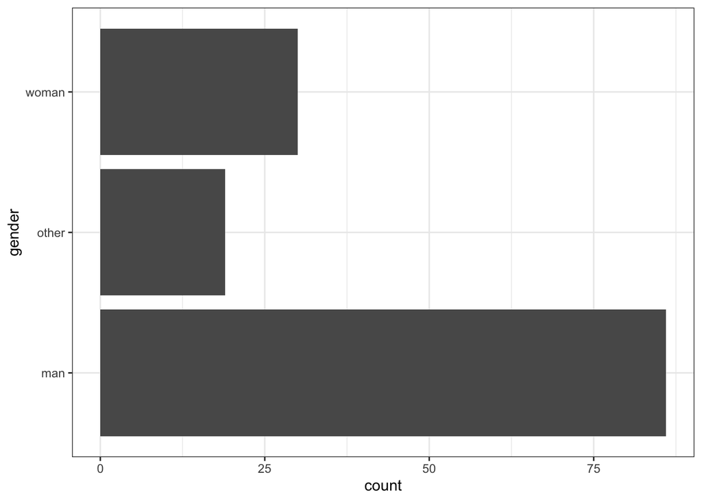

```r
df %>%
  filter(trial == 1) %>%
  rowwise() %>%
  mutate(
    gender = tolower(as.character(gender)),
    gender = case_when(
      grepl("woman", gender, fixed = TRUE) | grepl("female", gender, fixed = TRUE)       ~ "woman",
      (grepl("man", gender, fixed = TRUE) | grepl("male", gender, fixed = TRUE)) &
        ! (grepl("woman", gender, fixed = TRUE) | grepl("female", gender, fixed = TRUE)) ~ "man",
      TRUE                                                                               ~ "other")
  ) %>%
  ggplot(aes(y = gender)) +
    geom_bar() +
    theme_bw()
```

Let’s also check out age…

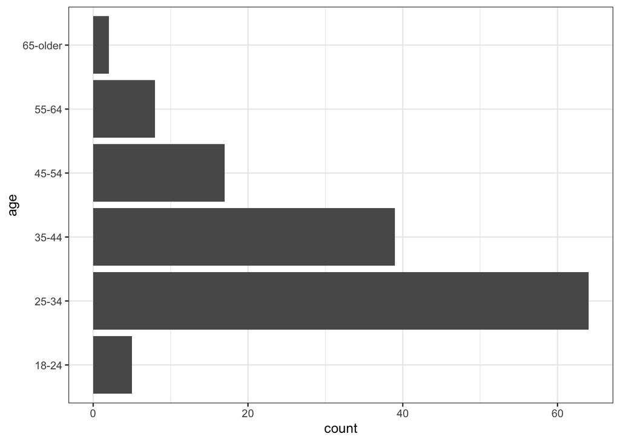

```r
df %>%
  filter(trial == 1) %>%
  ggplot(aes(y = age)) +
    geom_bar() +
    theme_bw()
```

… and education.

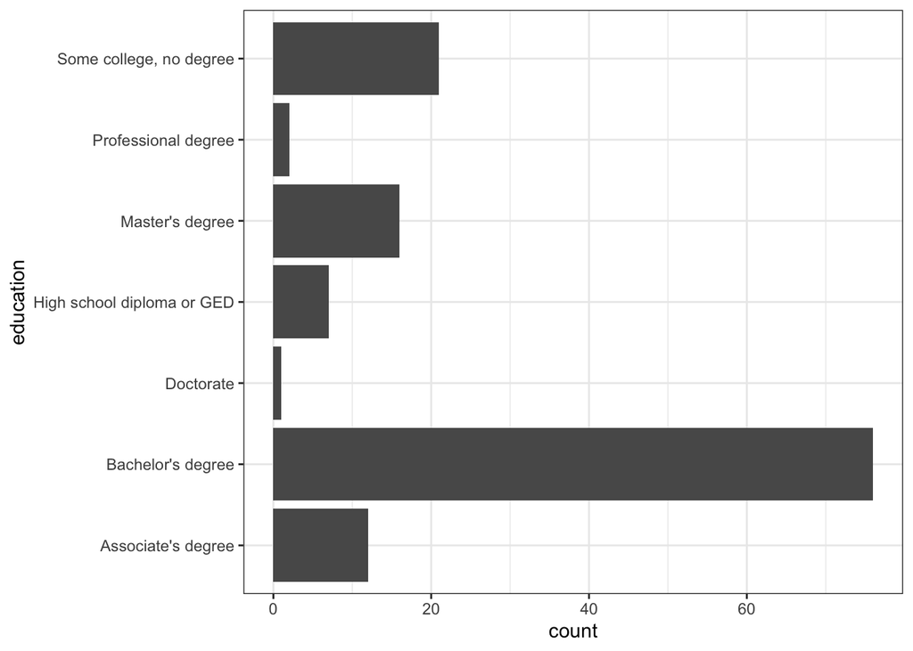

```r
df %>%
  filter(trial == 1) %>%
  ggplot(aes(y = education)) +
    geom_bar() +
    theme_bw()
```

Last, let’s look at chart use.

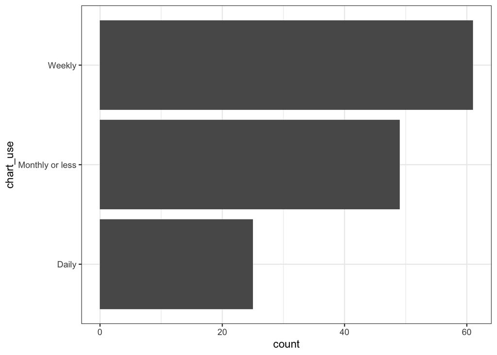

```r
df %>%
  filter(trial == 1) %>%
  ggplot(aes(y = chart_use)) +
    geom_bar() +
    theme_bw()
```

#### Covariate effects on performance

Education and chart use are the only demographic variables that we collected which I would expect to have an impact on performance.

Let’s check out the relationships of those variables with avg absolute error. (These charts no longer work after exclusions because, we don’t have enough data.)

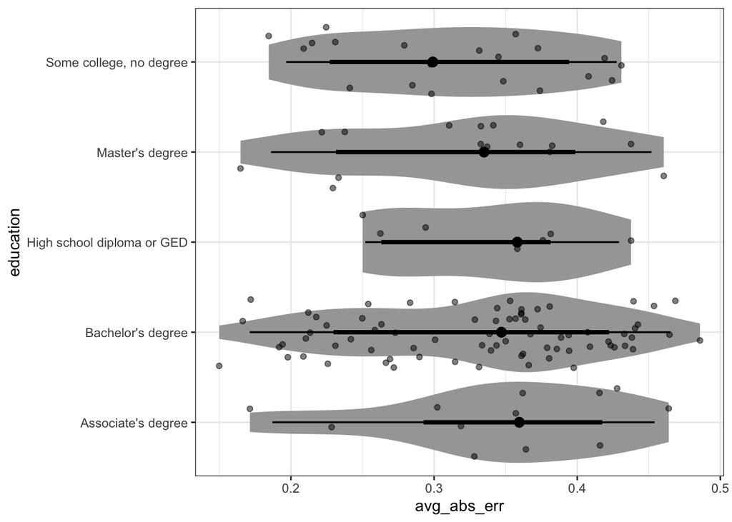

```r
df %>%
  group_by(education) %>%
  summarise(
    count = length(unique(workerId)),
    workerId = list(workerId),
    abs_err = list(abs_err)
  ) %>%
  unnest(cols = c("workerId", "abs_err")) %>%
  group_by(workerId, education) %>%
  summarise(
    avg_abs_err = mean(abs_err),
    count = unique(count)
  ) %>%
  ungroup() %>%
  filter(count > 2) %>%
  ggplot(aes(x = avg_abs_err, y = education)) +
    stat_eye() +
    geom_point(position = position_jitter(), alpha = 0.5) +
    theme_bw()
```

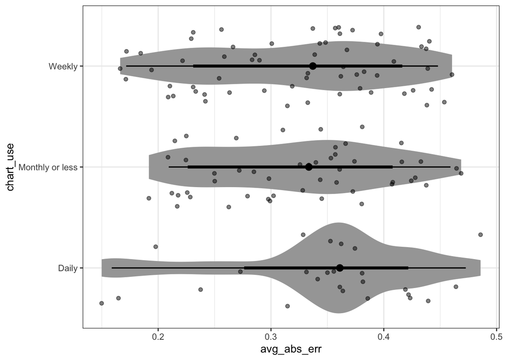

```r
df %>%
  group_by(workerId, chart_use) %>%
  summarise(
    avg_abs_err = mean(abs_err)
  ) %>%
  ungroup() %>%
  ggplot(aes(x = avg_abs_err, y = chart_use)) +
    stat_eye() +
    geom_point(position = position_jitter(), alpha = 0.5) +
    theme_bw()
```